```python
!pip install plotly
```

```python
import numpy as np
import pandas as pd
from pyscheduling.FS import FmCmax, FlowShop
import pickle
import time
from tabulate import tabulate
import matplotlib.pyplot as plt
import plotly.express as px
```

# Heuristiques pour PFSP

Dans cette première partie, nous allons présenter l'implémentation des différentes heuristiques en les testant sur une instance aléatoire générée avec PyScheduling. Nous affichions la séquence retournéepar chaque heuristique à travers un diagramme de gantt.

### Instance aléatoire

```python
instance=FmCmax.FmCmax_Instance.read_txt("./data/random_instance.txt")
n = instance.n
m = instance.m
M = np.array(instance.P)
M , M[n-1][m-1]
```

```
(array([[71, 79, 85, 82, 83],
        [84, 71, 66, 68, 81],
        [78, 81, 75, 72, 87],
        [78, 75, 66, 72, 88],
        [72, 88, 83, 85, 88],
        [86, 88, 79, 82, 78],
        [75, 66, 86, 78, 78],
        [80, 79, 66, 83, 78],
        [73, 73, 67, 77, 71],
        [80, 77, 83, 78, 67]]),
 67)
```

### Fonction du Makespan

```python
def compute_makespan(schedule, p):
    _, m = p.shape
    n = len(schedule)
    c = [[0]*m for i in range(n)]
    for i in range(n):
        for j in range(m):
            if i == 0 and j == 0:
                c[i][j] = p[schedule[i]][j]
            elif i == 0:
                c[i][j] = c[i][j-1] + p[schedule[i]][j]
            elif j == 0:
                c[i][j] = c[i-1][j] + p[schedule[i]][j]
            else:
                c[i][j] = max(c[i][j-1], c[i-1][j]) + p[schedule[i]][j]
    return c[n-1][m-1]
```

### Fonction d'affichage de Gantt

```python
def drawGantt(title,processing_time,solution,num_machines,num_jobs):
    data=[]
    prev=0
    for m in range(num_machines):
        data.append([{} for i in range(num_jobs)])
        prev=0
        for job in solution:
            value=max(prev,data[m-1][job]['end']) if m>0 else prev
            data[m][job]={'id':job , 'start': value, 'end': value+processing_time[job,m]}
            prev=value+processing_time[job,m]
    # Sort the jobs on each machine by their start time
    for m in  range(num_machines):
        data[m] = sorted(data[m], key=lambda x: x['start'])
    fig, ax = plt.subplots(figsize=(8, 4))

    colors = ['C0', 'C1', 'C2', 'C3', 'C4', 'C5', 'C6', 'C7', 'C8', 'C9', 'C10', 'C11','C12']
    for m in range(num_machines):
        for i, job in enumerate(data[m]):
            ax.barh(m+1, job['end'] - job['start'], left=job['start'], color=colors[i % len(colors)], align='center')
            ax.text(job['start'] + (job['end'] - job['start']) / 2, m+1, '', ha='center', va='center', color='white')

    last_time = max([job['end'] for jobs in data for job in jobs])

    ax.set_title(f'{title} Makespan: {last_time}')
    ax.set_xlabel('Time')
    ax.set_ylabel('Machine')

    ax.set_yticks(list(range(1,6)))
    ax.set_yticklabels([f'M{machine}' for machine in range(1,6)])

    ax.set_xlim(0, last_time)
#     ax.text(last_time + 8, 3, f'Objective: {last_time}', va='center')

    plt.show()
```

## Heuristique de Palmer

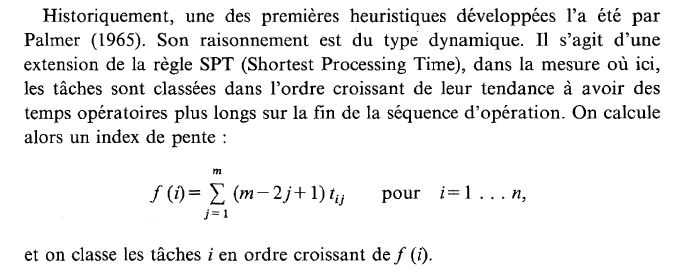

```python
def f_palmer(i,m,M):
    somme = 0
    for j in range(m):
        somme+= (m - 2*j + 1) * M[i][j]
    return somme


def heuristique_Palmer(M):
    n, m = M.shape

    list_taches = [i for i in range(n)]
    list_taches.sort( key=lambda i:  f_palmer(i,m,M) )

    return list_taches , compute_makespan(list_taches,M)
```

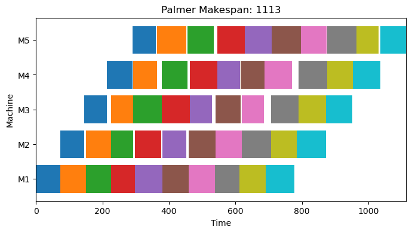

```python
res=heuristique_Palmer(M)
drawGantt("Palmer",M,res[0],5,10)
```

## Heuristique de Gupta

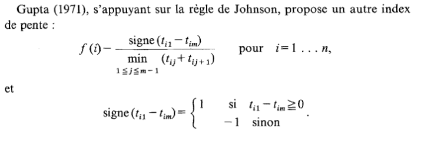

```python
def f_gupta(i,m,M):
    signe = np.sign(M[i][0] - M[i][m-1])
    minimum = np.min(np.array([M[i][j-1]+ M[i][j] for j in range(m) ]))
    return  signe / minimum


def heuristique_Gupta(M):
    n , m = M.shape

    list_taches = [i for i in range(n)]
    list_taches.sort( key=lambda i:  f_gupta(i,m,M) )

    return list_taches , compute_makespan(list_taches,M)
```

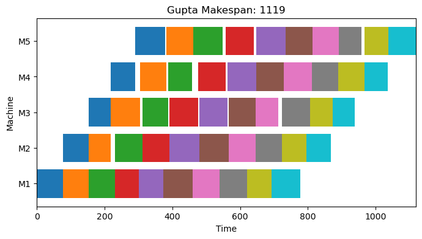

```python
res=heuristique_Gupta(M)
drawGantt("Gupta",M,res[0],5,10)
```

## Heuristique CDS de Campbell, Dudek et Smith

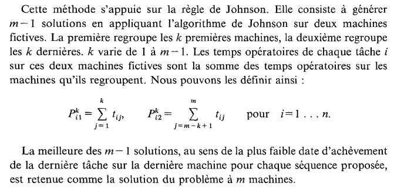

```python
def johnson_method(processing_times):

    jobs, machines = processing_times.shape
    #print(jobs,machines)
    copy_processing_times = processing_times.copy()
    maximum = processing_times.max() + 1
    m1 = []
    m2 = []

    if machines != 2:
        raise Exception("Johson method only works with two machines")

    for i in range(jobs):
        minimum = copy_processing_times.min()
        position = np.where(copy_processing_times == minimum)

        if position[1][0] == 0:
            m1.append(position[0][0])
        else:
            m2.insert(0, position[0][0])

        copy_processing_times[position[0][0]] = maximum
        # Delete the job appended
    return m1+m2
```

```python
def heuristique_CDS(M):
    m = M.shape[1]
    solutions = []
    makespans = []

    for k in range(1,m):
        P1 = M[:,0:k].sum(axis=1) # sommer les durées sur les k premières machines
        P2 = M[:,m-k:m].sum(axis=1) # sommer les durées sur les m-k dernières machines
        P1_P2 = np.hstack([P1[:,None],P2[:,None]]) # créer une matrice à deux colonnes avec P1 et P2

        johnson_seq = johnson_method(P1_P2) # appliquer la méthode de Johnson sur P1_P2

        solutions.append(johnson_seq)
        makespans.append(np.apply_along_axis(compute_makespan, 0, johnson_seq, M)) # calculer le makespan de v avec M

    score = np.min(makespans) # trouver le score minimal
    return solutions[np.argmin(makespans)], score # renvoyer la solution correspondant au score minimal
```

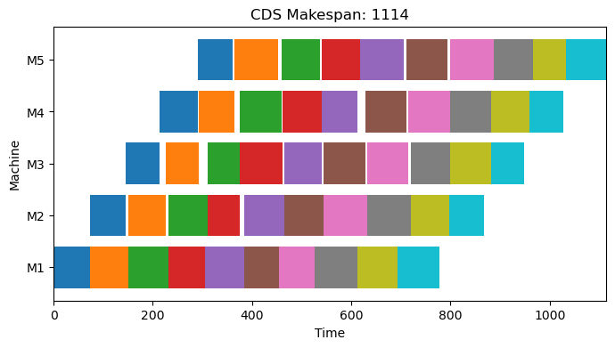

```python
res=heuristique_CDS(M)
drawGantt("CDS",M,res[0],5,10)
```

## Heuristique de PPE de Park, Pegden et Enscore

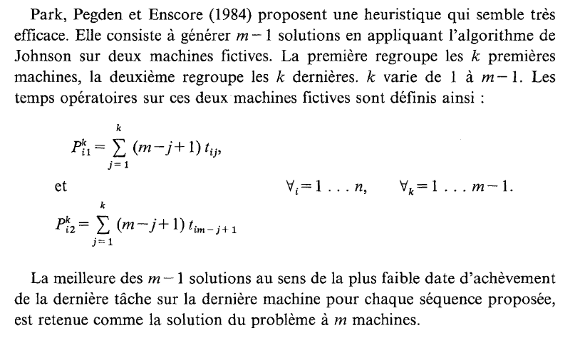

```python
def heuristique_PPE(M):
    m = M.shape[1]
    solutions = []
    makespans = []

    for k in range(1,m):

        alpha = [m - j + 1 for j in range(k)]

        alpha = np.tile(alpha, (M.shape[0], 1)) # répéter le vecteur alpha

        P1 = np.sum(M[:, 0:k] * alpha, axis=1) # calculer la somme des lignes
        P2 = np.sum(M[:, m-k:m] * alpha, axis=1)

        z = np.hstack([P1[:,None],P2[:,None]]) # créer une matrice à deux colonnes avec P1 et P2

        v = johnson_method(z) # appliquer la méthode de Johnson sur z

        solutions.append(v)
        makespans.append(np.apply_along_axis(compute_makespan,0,v,M)) # calculer le makespan de v avec M

    score = np.min(makespans) # trouver le score minimal
    return solutions[np.argmin(makespans)], score # renvoyer la solution correspondant au score minimal
```

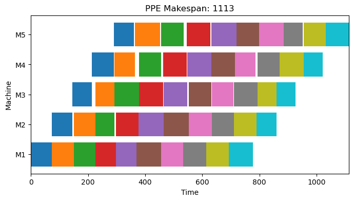

```python
res=heuristique_PPE(M)
drawGantt("PPE",M,res[0],5,10)
```

## Heuristique de Hundal et Rajgopal

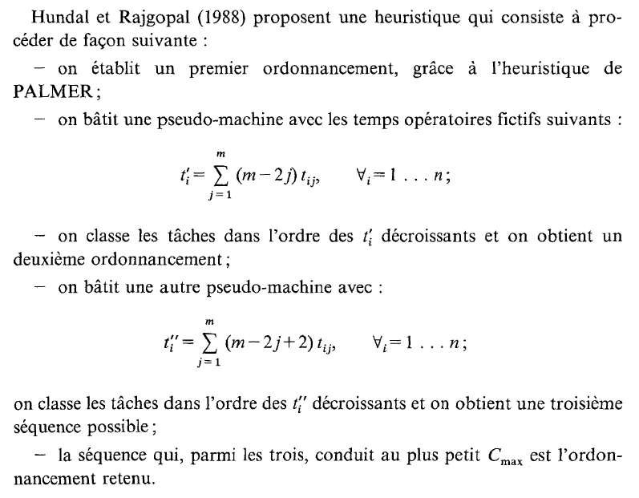

```python
def heuristique_Hundal_Rajgopal(M):
    m = M.shape[1]

    # 1e ordonnancement avec PALMER
    seq_PALMER, makespan_PALMER = heuristique_Palmer(M)

    # 2e ordonnancement
    alpha = [ m - 2*j for j in range(m)]
    alpha = np.tile(alpha, (M.shape[0], 1)) # répéter le vecteur alpha
    T1 = np.sum(M[:, 0:m] * alpha, axis=1) # calculer la somme des lignes

    liste_tache = np.arange(M.shape[0])
    seq_T1 = liste_tache[np.argsort(-T1)]

    # 3e ordonnancement
    alpha = [ m - 2*j + 2 for j in range(m)]

    alpha = np.tile(alpha, (M.shape[0], 1)) # répéter le vecteur alpha
    T1 = np.sum(M[:, 0:m] * alpha, axis=1) # calculer la somme des lignes

    liste_tache = np.arange(M.shape[0])
    seq_T2 = liste_tache[np.argsort(-T1)]

    # Comparaison
    makespan_T1 = compute_makespan(seq_T1 , M)
    makespan_T2 = compute_makespan(seq_T2 , M)

    best_makespan = np.array([makespan_PALMER, makespan_T1 , makespan_T1])

    best_makespan = np.argmin(best_makespan)

    seq_dict = {0: ('Palmer', seq_PALMER, makespan_PALMER), 1: ("t'", seq_T1, makespan_T1), 2: ("t''", seq_T2, makespan_T2)}

    return seq_dict[best_makespan][-2:] # retourne le tuple correspondant à l'indice
```

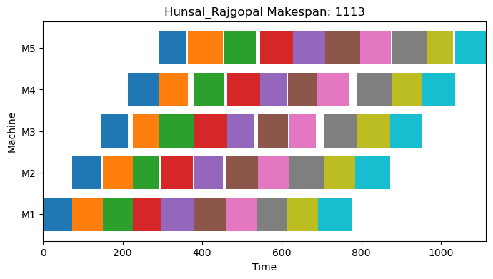

```python
res=heuristique_Hundal_Rajgopal(M)
drawGantt("Hunsal_Rajgopal",M,res[0],5,10)
```

## Heuristique de HAM

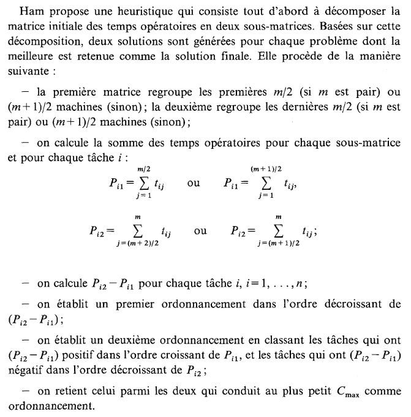

```python
def heuristique_Ham(M):
    m = M.shape[1]

    P1 = np.sum(M[:,:m//2], axis=1) # somme des durées sur la première machine
    P2 = np.sum(M[:,m//2:], axis=1) # somme des durées sur la deuxième machine
    P2_P1 = P2 - P1 # différence entre les deux sommes
    ordre = np.flip(np.argsort(P2_P1)) # tri par ordre décroissant

    # Première solution
    ordre_1 = ordre
    Cmax1 = compute_makespan(ordre_1 , M) # makespan de la première solution

    # Deuxième solution
    indice_positif = ordre[P2_P1[ordre] >= 0] # indices des tâches avec un indice positif ou nul
    indice_negatif = ordre[P2_P1[ordre] < 0] # indices des tâches avec un indice négatif

    indice_positif = [indice_positif[i] for i in np.argsort(P1[indice_positif])] # tri croissant selon P1
    indice_negatif = [indice_negatif[i] for i in np.flip(np.argsort(P2[indice_negatif]))] # tri décroissant selon P2

    ordre_2 = [int(i) for i in np.concatenate((indice_positif, indice_negatif))]
    Cmax2 = compute_makespan(ordre_2 , M) # makespan de la deuxième solution

    if (Cmax1 > Cmax2):
        return ordre_1, Cmax1
    else:
        return ordre_2, Cmax2
```

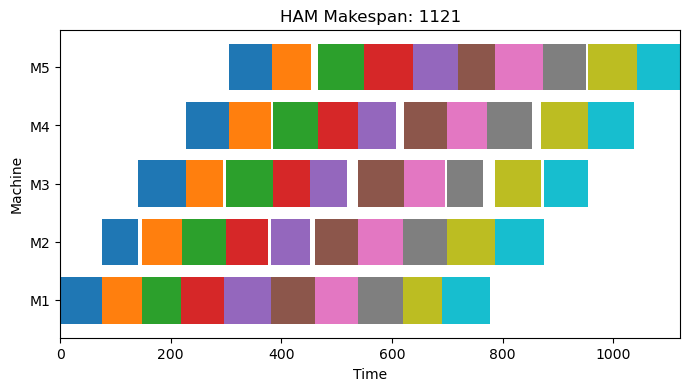

```python
res= heuristique_Ham(M)
drawGantt("HAM",M,res[0],5,10)
```

## Heuristique de NEH

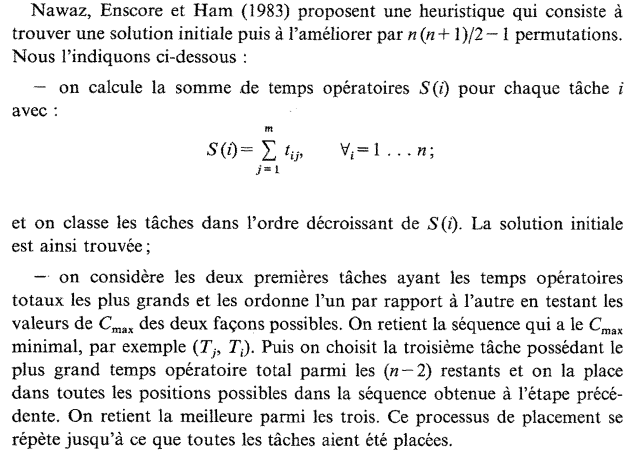

```python
def heuristique_NEH(M):
    n , m = M.shape
    p = M.copy()

    # Step 1: Compute the processing time of each job
    processing_time = [sum(p[i]) for i in range(n)]

    # Step 2: Sort the jobs in decreasing order of processing time
    sorted_jobs = sorted(range(n), key=lambda i: processing_time[i], reverse=True)

    # Step 3: Initialize the schedule with the first job
    schedule = [sorted_jobs[0]]

    # Step 4: Insert each subsequent job into the schedule in a position that minimizes the makespan
    for i in range(1, n):
        best_pos = -1
        best_makespan = float('inf')
        for j in range(len(schedule)+1):
            temp_schedule = schedule[:j] + [sorted_jobs[i]] + schedule[j:]
            temp_makespan = compute_makespan(temp_schedule, p)
            if temp_makespan < best_makespan:
                best_makespan = temp_makespan
                best_pos = j
        schedule.insert(best_pos, sorted_jobs[i])

    return schedule, compute_makespan(schedule, p)
```

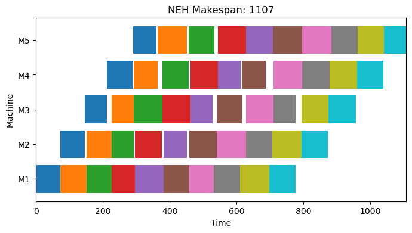

```python
res=heuristique_NEH(M)
drawGantt("NEH",M,res[0],5,10)
```

## Improved NEH

Une amélioration de l'heuristique NEH. Propose une nouvelle règle de priorité basée sur l'asymétrie afin d'améliorer les performances de NEH pour le PFSP. L'asymétrie est définie comme étant les moments d'ordre 1, 2 et 3 de la distribution de probabilité des temps de traitement des tâches.

Une nouvelle règle de rupture d'égalité (tie breaker) est également proposée pour minimiser le temps d'inactivité partiel du système sans augmenter la complexité.

```python
from scipy.stats import skew
```

```python
def heuristique_improved_NEH(M):
    n , m = M.shape
    p = M.copy()

    # Step 2: Sort the jobs in decreasing order of processing time
    sorted_jobs = sorted(range(n), key=lambda i: np.mean(p[i]) + np.std(p[i]) + skew(p[i]), reverse=True)

    # Step 3: Initialize the schedule with the first job
    schedule = [sorted_jobs[0]]

    # Step 4: Insert each subsequent job into the schedule in a position that minimizes the makespan
    for i in range(1, n):
        best_pos = -1
        best_makespan = float('inf')
        for j in range(len(schedule)+1):
            temp_schedule = schedule[:j] + [sorted_jobs[i]] + schedule[j:]
            temp_makespan = compute_makespan(temp_schedule, p)
            if temp_makespan < best_makespan:
                best_makespan = temp_makespan
                best_pos = j
        schedule.insert(best_pos, sorted_jobs[i])

    return schedule, compute_makespan(schedule, p)
```

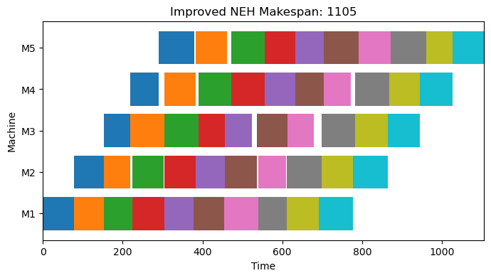

```python
res=heuristique_improved_NEH(M)
drawGantt("Improved NEH",M,res[0],5,10)
```

## Heuristique SULIMAN

Suliman est une heuristique d'amélioration.

Dans la première phase, une séquence est généré à l'aide de la méthode heuristique NEH. Dans la deuxième phase, la séquence générée est améliorée par un mécanisme d'échange de paires de tâches. Afin de réduire la charge de calcul d'un mécanisme d'échange de paires exhaustif, une contrainte de directionnalité est imposée pour réduire l'espace de recherche.

```python
def suliman_heuristic(initial_permutation, job_times):
    """
    Takes an initial permutation and the processing times of each job,
    and returns an improved permutation using Suliman's heuristic.
    """
    n_jobs = len(job_times)
    permutation = initial_permutation[:]
    best_makespan = compute_makespan(permutation, job_times)

    improved = True

    while improved:
        improved = False
        for i in range(n_jobs - 1):
            new_permutation = permutation[:]
            new_permutation[i], new_permutation[i+1] = new_permutation[i+1], new_permutation[i]
            new_makespan = compute_makespan(new_permutation, job_times)
            if new_makespan < best_makespan:
                permutation = new_permutation
                best_makespan = new_makespan
                improved = True
    improved = True

    return permutation,best_makespan
def suliman_heuristic_v2(initial_permutation, job_times):
    """
    Takes an initial permutation and the processing times of each job,
    and returns an improved permutation using a modified version of Suliman's heuristic.
    """
    n_jobs = len(job_times)
    permutation = initial_permutation[:]
    best_makespan = compute_makespan(permutation, job_times)

    improved = True

    while improved:
        improved = False
        for i in range(n_jobs - 1):
            for j in range(i+2, n_jobs):
                new_permutation = permutation[:]
                # Swap jobs i and j
                new_permutation[i], new_permutation[j] = new_permutation[j], new_permutation[i]
                new_makespan = compute_makespan(new_permutation, job_times)
                if new_makespan < best_makespan:
                    permutation = new_permutation
                    best_makespan = new_makespan
                    improved = True

    return permutation, best_makespan

def compute_makespan(schedule, p):
    _, m = p.shape
    n = len(schedule)
    c = [[0]*m for i in range(n)]
    for i in range(n):
        for j in range(m):
            if i == 0 and j == 0:
                c[i][j] = p[schedule[i]][j]
            elif i == 0:
                c[i][j] = c[i][j-1] + p[schedule[i]][j]
            elif j == 0:
                c[i][j] = c[i-1][j] + p[schedule[i]][j]
            else:
                c[i][j] = max(c[i][j-1], c[i-1][j]) + p[schedule[i]][j]
    return c[n-1][m-1]
```

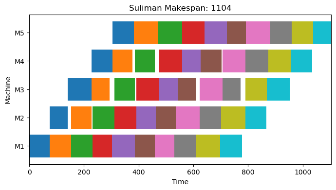

```python
initial_permutation,initial_makespan=heuristique_NEH(M)
res=suliman_heuristic_v2(initial_permutation,M)
drawGantt("Suliman",M,res[0],5,10)
```

# Tests avec intances de Taillard

Dans cette partie, nous allons Exécuter les heuristiques implémentées sur les instances : 1, 2, 7,9 et 10 des banchmarks : 1, 2, 3, 4, 7 et 11 de Taillard. Pour chaque instance, nous calculons le makespan retournée par chaque heuristique, la déviation par rapport à l'upper bound de Taillard ainsi que le temps d'exécution. Un histogramme comparant les résultats obtenus par les différentes heurostiques sur toutes les instances est présenté à la fin de chaque benchmark.

- Note : Les cellules qui suivent ont été exécutées séquentiellement au préalable, une exécution non séquentielle peut causer des erreurs d'affichage ( décalage des résultats entre les benchmarks car les memes variables ont été utilisés )

```python
heuristics = { heuristique_Palmer , heuristique_Gupta, heuristique_CDS, heuristique_PPE, heuristique_Hundal_Rajgopal, heuristique_Ham, heuristique_NEH, heuristique_improved_NEH  }
```

## Benchmark 1 : 20 jobs 5 machines

```python
# Exécution des heuristiques sur toutes les instances du Bnechmark
sequences = []
makespans = []
times = []
deviations = []
rows = []
headers = ['Instance', 'Heuristique' , 'Makespan', 'Time (s)', 'Deviation %', 'Séquence retournée']
f =  open("./data/Taillard.pkl", "rb")
taillard = pickle.load(f)

for instance_id in {0,1,6,8,9}:

    M = np.array(taillard[instance_id]["P"]).transpose()
    upper_bound = taillard[instance_id]["ub"]
    lower_bound = taillard[instance_id]["lb"]

    for h in heuristics:
        start_time = time.time()
        sequence , cost = h(M)
        end_time = time.time()
        sequences.append(sequence)
        makespans.append(cost)
        times.append(round(end_time - start_time, 2))
        deviation = 100 * (cost - upper_bound ) / cost
        deviations.append(deviation)
        rows.append([instance_id,h.__name__,cost,round(end_time - start_time, 2),deviation,sequence])
```

### Instance 1

```python
data = pd.DataFrame(rows, columns=headers)
data[data["Instance"]==0]
```

|  | Instance | Heuristique | Makespan | Time (s) | Deviation % | Séquence retournée |
| --- | --- | --- | --- | --- | --- | --- |
| 0 | 0 | heuristique_Ham | 1437 | 0.02 | 11.064718 | [8, 18, 1, 14, 10, 4, 16, 15, 2, 5, 13, 7, 12,... |
| 1 | 0 | heuristique_CDS | 1390 | 0.00 | 8.057554 | [14, 2, 8, 13, 16, 7, 6, 0, 18, 3, 10, 15, 11,... |
| 2 | 0 | heuristique_NEH | 1286 | 0.05 | 0.622084 | [2, 16, 8, 7, 14, 13, 10, 15, 12, 18, 5, 3, 4,... |
| 3 | 0 | heuristique_Hundal_Rajgopal | 1378 | 0.00 | 7.256894 | [8, 2, 16, 14, 10, 7, 15, 18, 13, 12, 5, 0, 1,... |
| 4 | 0 | heuristique_PPE | 1390 | 0.00 | 8.057554 | [14, 2, 8, 13, 16, 7, 6, 0, 18, 3, 10, 15, 11,... |
| 5 | 0 | heuristique_Palmer | 1378 | 0.00 | 7.256894 | [8, 2, 16, 14, 10, 7, 15, 18, 13, 12, 5, 0, 1,... |
| 6 | 0 | heuristique_improved_NEH | 1297 | 0.02 | 1.464919 | [2, 14, 16, 13, 8, 12, 0, 5, 7, 18, 15, 6, 4, ... |
| 7 | 0 | heuristique_Gupta | 1446 | 0.00 | 11.618257 | [10, 2, 8, 16, 14, 15, 13, 7, 0, 3, 6, 18, 4, ... |

### Instance 2

```python
data[data["Instance"]==1]
```

|  | Instance | Heuristique | Makespan | Time (s) | Deviation % | Séquence retournée |
| --- | --- | --- | --- | --- | --- | --- |
| 8 | 1 | heuristique_Ham | 1488 | 0.02 | 8.669355 | [14, 9, 2, 11, 8, 0, 19, 3, 1, 6, 16, 10, 4, 5... |
| 9 | 1 | heuristique_CDS | 1424 | 0.00 | 4.564607 | [5, 18, 16, 14, 2, 19, 6, 11, 8, 0, 12, 1, 10,... |
| 10 | 1 | heuristique_NEH | 1365 | 0.01 | 0.439560 | [18, 13, 5, 19, 2, 9, 16, 8, 17, 11, 6, 14, 0,... |
| 11 | 1 | heuristique_Hundal_Rajgopal | 1469 | 0.00 | 7.488087 | [14, 8, 13, 19, 9, 2, 11, 0, 5, 6, 16, 18, 1, ... |
| 12 | 1 | heuristique_PPE | 1425 | 0.00 | 4.631579 | [14, 5, 2, 18, 19, 16, 8, 11, 6, 0, 1, 12, 7, ... |
| 13 | 1 | heuristique_Palmer | 1469 | 0.00 | 7.488087 | [14, 8, 13, 19, 9, 2, 11, 0, 5, 6, 16, 18, 1, ... |
| 14 | 1 | heuristique_improved_NEH | 1397 | 0.03 | 2.720115 | [19, 2, 13, 9, 16, 17, 6, 14, 11, 15, 8, 10, 1... |
| 15 | 1 | heuristique_Gupta | 1380 | 0.00 | 1.521739 | [18, 5, 19, 14, 16, 2, 11, 8, 0, 6, 12, 10, 4,... |

### Instance 7

```python
data[data["Instance"]==6]
```

|  | Instance | Heuristique | Makespan | Time (s) | Deviation % | Séquence retournée |
| --- | --- | --- | --- | --- | --- | --- |
| 16 | 6 | heuristique_Ham | 1446 | 0.00 | 14.315353 | [4, 9, 10, 0, 14, 15, 1, 12, 8, 19, 17, 7, 16,... |
| 17 | 6 | heuristique_CDS | 1393 | 0.01 | 11.055276 | [9, 4, 14, 10, 0, 15, 6, 12, 7, 3, 19, 1, 5, 1... |
| 18 | 6 | heuristique_NEH | 1278 | 0.01 | 3.051643 | [4, 15, 14, 13, 1, 10, 0, 19, 12, 7, 5, 8, 6, ... |
| 19 | 6 | heuristique_Hundal_Rajgopal | 1487 | 0.00 | 16.677875 | [4, 10, 9, 0, 14, 12, 15, 1, 19, 8, 13, 17, 18... |
| 20 | 6 | heuristique_PPE | 1393 | 0.00 | 11.055276 | [9, 4, 14, 10, 0, 15, 6, 12, 7, 3, 19, 1, 5, 1... |
| 21 | 6 | heuristique_Palmer | 1487 | 0.00 | 16.677875 | [4, 10, 9, 0, 14, 12, 15, 1, 19, 8, 13, 17, 18... |
| 22 | 6 | heuristique_improved_NEH | 1255 | 0.00 | 1.274900 | [4, 14, 15, 0, 3, 1, 13, 19, 10, 18, 16, 2, 7,... |
| 23 | 6 | heuristique_Gupta | 1385 | 0.00 | 10.541516 | [4, 9, 10, 1, 6, 0, 15, 14, 3, 12, 19, 7, 5, 2... |

### Instance 9

```python
data[data["Instance"]==8]
```

|  | Instance | Heuristique | Makespan | Time (s) | Deviation % | Séquence retournée |
| --- | --- | --- | --- | --- | --- | --- |
| 24 | 8 | heuristique_Ham | 1538 | 0.00 | 20.026008 | [16, 17, 1, 3, 0, 2, 6, 11, 19, 15, 9, 10, 18,... |
| 25 | 8 | heuristique_CDS | 1360 | 0.02 | 9.558824 | [3, 1, 6, 7, 11, 9, 19, 17, 2, 0, 16, 5, 8, 10... |
| 26 | 8 | heuristique_NEH | 1291 | 0.00 | 4.725019 | [3, 1, 19, 17, 16, 14, 0, 9, 6, 8, 15, 12, 7, ... |
| 27 | 8 | heuristique_Hundal_Rajgopal | 1314 | 0.00 | 6.392694 | [3, 1, 16, 9, 6, 11, 7, 15, 0, 2, 17, 19, 14, ... |
| 28 | 8 | heuristique_PPE | 1390 | 0.00 | 11.510791 | [3, 9, 15, 7, 6, 1, 11, 16, 17, 0, 19, 2, 10, ... |
| 29 | 8 | heuristique_Palmer | 1314 | 0.00 | 6.392694 | [3, 1, 16, 9, 6, 11, 7, 15, 0, 2, 17, 19, 14, ... |
| 30 | 8 | heuristique_improved_NEH | 1275 | 0.02 | 3.529412 | [3, 15, 1, 11, 9, 19, 0, 10, 17, 16, 6, 14, 8,... |
| 31 | 8 | heuristique_Gupta | 1435 | 0.00 | 14.285714 | [3, 9, 7, 1, 6, 2, 11, 16, 17, 0, 19, 5, 10, 1... |

### Instance 10

```python
data[data["Instance"]==9]
```

|  | Instance | Heuristique | Makespan | Time (s) | Deviation % | Séquence retournée |
| --- | --- | --- | --- | --- | --- | --- |
| 32 | 9 | heuristique_Ham | 1300 | 0.00 | 14.769231 | [9, 5, 18, 4, 6, 15, 1, 11, 7, 12, 10, 2, 0, 3... |
| 33 | 9 | heuristique_CDS | 1164 | 0.00 | 4.810997 | [4, 6, 10, 15, 18, 11, 5, 0, 9, 12, 7, 1, 2, 3... |
| 34 | 9 | heuristique_NEH | 1151 | 0.02 | 3.735882 | [6, 18, 10, 11, 15, 5, 0, 12, 9, 14, 1, 7, 2, ... |
| 35 | 9 | heuristique_Hundal_Rajgopal | 1247 | 0.00 | 11.146752 | [6, 10, 15, 4, 18, 5, 9, 11, 0, 8, 12, 17, 7, ... |
| 36 | 9 | heuristique_PPE | 1239 | 0.00 | 10.573043 | [4, 6, 10, 15, 18, 11, 9, 5, 0, 7, 1, 2, 3, 12... |
| 37 | 9 | heuristique_Palmer | 1247 | 0.00 | 11.146752 | [6, 10, 15, 4, 18, 5, 9, 11, 0, 8, 12, 17, 7, ... |
| 38 | 9 | heuristique_improved_NEH | 1141 | 0.02 | 2.892200 | [6, 10, 4, 11, 15, 5, 9, 17, 13, 12, 7, 18, 1,... |
| 39 | 9 | heuristique_Gupta | 1213 | 0.00 | 8.656224 | [6, 18, 10, 15, 9, 0, 11, 5, 7, 2, 1, 3, 16, 1... |

### Comparaison des résultats sur le premier Benchmark

```python
import plotly.graph_objects as go
from plotly.offline import iplot, init_notebook_mode
init_notebook_mode(connected=True)

instances = ["1","2","7","9","10"]

fig = go.Figure()
fig.add_trace(go.Bar(
    x=instances,
    y=data[data["Heuristique"]=="heuristique_Gupta"]["Deviation %"],
    name='Gupta',
    marker_color='darkgoldenrod'
))
fig.add_trace(go.Bar(
    x=instances,
    y=data[data["Heuristique"]=="heuristique_Ham"]["Deviation %"],
    name='Ham',
    marker_color='darkred'
))
fig.add_trace(go.Bar(
    x=instances,
    y=data[data["Heuristique"]=="heuristique_Palmer"]["Deviation %"],
    name='Palmer',
    marker_color='steelblue'
))
fig.add_trace(go.Bar(
    x=instances,
    y=data[data["Heuristique"]=="heuristique_Hundal_Rajgopal"]["Deviation %"],
    name='Hundal_Rajgopal',
    marker_color='palevioletred'
))
fig.add_trace(go.Bar(
    x=instances,
    y=data[data["Heuristique"]=="heuristique_PPE"]["Deviation %"],
    name='PPE',
    marker_color='teal'
))
fig.add_trace(go.Bar(
    x=instances,
    y=data[data["Heuristique"]=="heuristique_CDS"]["Deviation %"],
    name='CDS',
    marker_color='orange'
))
fig.add_trace(go.Bar(
    x=instances,
    y=data[data["Heuristique"]=="heuristique_NEH"]["Deviation %"],
    name='NEH',
    marker_color='olive'
))
fig.add_trace(go.Bar(
    x=instances,
    y=data[data["Heuristique"]=="heuristique_improved_NEH"]["Deviation %"],
    name='Improved NEH',
    marker_color='slategray'
))


# Here we modify the tickangle of the xaxis, resulting in rotated labels.
fig.update_layout(barmode='group', xaxis_tickangle=-45, xaxis_title ="Instance", yaxis_title="Deviation", title_text="Déviation des résultats des heuristiques sur les instances du 1er benchmark")
fig.show()
```

[interactive chart not shown]

## Benchmark 2

```python
# Exécution des heuristiques sur toutes les instances du Bnechmark

rows = []
headers = ['Instance', 'Heuristique' , 'Makespan', 'Time (s)', 'Deviation %', 'Séquence retournée']
f =  open("./data/Taillard2.pkl", "rb")
taillard = pickle.load(f)

for instance_id in {0,1,6,8,9}:

    M = np.array(taillard[instance_id]["P"]).transpose()
    upper_bound = taillard[instance_id]["ub"]
    lower_bound = taillard[instance_id]["lb"]

    for h in heuristics:
        start_time = time.time()
        sequence , cost = h(M)
        end_time = time.time()
        deviation = 100 * (cost - upper_bound ) / cost
        rows.append([instance_id,h.__name__,cost,round(end_time - start_time, 2),deviation,sequence])
```

### Instance 1

```python
data = pd.DataFrame(rows, columns=headers)
data[data["Instance"]==0]
```

|  | Instance | Heuristique | Makespan | Time (s) | Deviation % | Séquence retournée |
| --- | --- | --- | --- | --- | --- | --- |
| 0 | 0 | heuristique_Ham | 1926 | 0.00 | 17.860852 | [17, 4, 16, 11, 2, 3, 10, 14, 9, 8, 19, 6, 12,... |
| 1 | 0 | heuristique_CDS | 1757 | 0.00 | 9.960159 | [1, 16, 17, 4, 8, 14, 11, 19, 3, 5, 6, 12, 18,... |
| 2 | 0 | heuristique_NEH | 1680 | 0.03 | 5.833333 | [17, 4, 1, 16, 2, 5, 11, 8, 14, 9, 19, 12, 7, ... |
| 3 | 0 | heuristique_Hundal_Rajgopal | 1812 | 0.00 | 12.693157 | [4, 17, 16, 1, 11, 3, 8, 14, 2, 19, 10, 5, 9, ... |
| 4 | 0 | heuristique_PPE | 1760 | 0.00 | 10.113636 | [4, 17, 1, 3, 8, 16, 5, 14, 6, 11, 12, 19, 9, ... |
| 5 | 0 | heuristique_Palmer | 1812 | 0.00 | 12.693157 | [4, 17, 16, 1, 11, 3, 8, 14, 2, 19, 10, 5, 9, ... |
| 6 | 0 | heuristique_improved_NEH | 1680 | 0.02 | 5.833333 | [3, 4, 14, 8, 11, 9, 5, 19, 12, 7, 17, 13, 18,... |
| 7 | 0 | heuristique_Gupta | 1984 | 0.00 | 20.262097 | [1, 7, 16, 11, 3, 4, 8, 5, 14, 18, 12, 9, 6, 1... |

### Instance 2

```python
data[data["Instance"]==1]
```

|  | Instance | Heuristique | Makespan | Time (s) | Deviation % | Séquence retournée |
| --- | --- | --- | --- | --- | --- | --- |
| 8 | 1 | heuristique_Ham | 2091 | 0.00 | 20.659971 | [11, 8, 3, 14, 18, 19, 5, 2, 16, 0, 7, 6, 4, 1... |
| 9 | 1 | heuristique_CDS | 1854 | 0.00 | 10.517799 | [7, 1, 18, 4, 16, 11, 19, 14, 12, 10, 8, 15, 0... |
| 10 | 1 | heuristique_NEH | 1729 | 0.02 | 4.048583 | [16, 11, 4, 12, 14, 6, 19, 8, 10, 18, 9, 0, 5,... |
| 11 | 1 | heuristique_Hundal_Rajgopal | 1919 | 0.00 | 13.548723 | [11, 16, 8, 18, 14, 4, 12, 1, 6, 0, 19, 10, 7,... |
| 12 | 1 | heuristique_PPE | 1854 | 0.02 | 10.517799 | [7, 1, 18, 4, 16, 11, 19, 14, 12, 10, 8, 15, 0... |
| 13 | 1 | heuristique_Palmer | 1919 | 0.00 | 13.548723 | [11, 16, 8, 18, 14, 4, 12, 1, 6, 0, 19, 10, 7,... |
| 14 | 1 | heuristique_improved_NEH | 1691 | 0.03 | 1.892371 | [11, 16, 14, 18, 8, 0, 4, 19, 6, 10, 5, 1, 12,... |
| 15 | 1 | heuristique_Gupta | 1961 | 0.00 | 15.400306 | [8, 7, 12, 14, 10, 11, 1, 16, 19, 18, 4, 9, 0,... |

### Instance 7

```python
data[data["Instance"]==6]
```

|  | Instance | Heuristique | Makespan | Time (s) | Deviation % | Séquence retournée |
| --- | --- | --- | --- | --- | --- | --- |
| 16 | 6 | heuristique_Ham | 1716 | 0.00 | 13.519814 | [18, 0, 5, 2, 3, 4, 6, 19, 15, 17, 8, 11, 16, ... |
| 17 | 6 | heuristique_CDS | 1630 | 0.00 | 8.957055 | [18, 3, 5, 6, 2, 15, 0, 4, 8, 16, 17, 1, 19, 1... |
| 18 | 6 | heuristique_NEH | 1562 | 0.02 | 4.993598 | [18, 5, 6, 9, 2, 16, 0, 3, 7, 19, 17, 8, 1, 4,... |
| 19 | 6 | heuristique_Hundal_Rajgopal | 1717 | 0.00 | 13.570181 | [18, 6, 3, 5, 0, 17, 15, 16, 2, 8, 19, 4, 9, 1... |
| 20 | 6 | heuristique_PPE | 1625 | 0.02 | 8.676923 | [18, 3, 6, 5, 0, 2, 15, 17, 8, 19, 11, 1, 13, ... |
| 21 | 6 | heuristique_Palmer | 1717 | 0.00 | 13.570181 | [18, 6, 3, 5, 0, 17, 15, 16, 2, 8, 19, 4, 9, 1... |
| 22 | 6 | heuristique_improved_NEH | 1543 | 0.02 | 3.823720 | [18, 3, 6, 9, 2, 5, 16, 15, 8, 12, 0, 17, 19, ... |
| 23 | 6 | heuristique_Gupta | 1750 | 0.00 | 15.200000 | [3, 17, 18, 15, 6, 16, 12, 0, 8, 19, 1, 13, 14... |

### Instance 9

```python
data[data["Instance"]==8]
```

|  | Instance | Heuristique | Makespan | Time (s) | Deviation % | Séquence retournée |
| --- | --- | --- | --- | --- | --- | --- |
| 24 | 8 | heuristique_Ham | 1964 | 0.00 | 18.890020 | [16, 1, 19, 3, 11, 5, 17, 10, 18, 0, 13, 7, 6,... |
| 25 | 8 | heuristique_CDS | 1720 | 0.00 | 7.383721 | [11, 16, 13, 5, 10, 19, 7, 3, 1, 15, 0, 17, 6,... |
| 26 | 8 | heuristique_NEH | 1647 | 0.02 | 3.278689 | [13, 11, 7, 16, 3, 10, 1, 19, 0, 18, 15, 2, 12... |
| 27 | 8 | heuristique_Hundal_Rajgopal | 1900 | 0.00 | 16.157895 | [1, 16, 13, 3, 7, 19, 11, 10, 15, 5, 17, 0, 6,... |
| 28 | 8 | heuristique_PPE | 1732 | 0.00 | 8.025404 | [11, 13, 16, 10, 5, 7, 19, 3, 1, 15, 0, 17, 4,... |
| 29 | 8 | heuristique_Palmer | 1900 | 0.00 | 16.157895 | [1, 16, 13, 3, 7, 19, 11, 10, 15, 5, 17, 0, 6,... |
| 30 | 8 | heuristique_improved_NEH | 1663 | 0.03 | 4.209260 | [7, 10, 13, 11, 3, 1, 0, 6, 18, 2, 19, 15, 16,... |
| 31 | 8 | heuristique_Gupta | 1823 | 0.00 | 12.616566 | [16, 13, 7, 1, 3, 10, 15, 19, 14, 9, 6, 18, 0,... |

### Instance 10

```python
data[data["Instance"]==9]
```

|  | Instance | Heuristique | Makespan | Time (s) | Deviation % | Séquence retournée |
| --- | --- | --- | --- | --- | --- | --- |
| 32 | 9 | heuristique_Ham | 1928 | 0.00 | 17.479253 | [16, 15, 18, 4, 3, 12, 9, 7, 6, 1, 19, 17, 8, ... |
| 33 | 9 | heuristique_CDS | 1884 | 0.00 | 15.552017 | [5, 15, 16, 3, 4, 18, 12, 1, 7, 9, 6, 14, 17, ... |
| 34 | 9 | heuristique_NEH | 1653 | 0.03 | 3.750756 | [4, 12, 16, 8, 18, 3, 6, 7, 15, 5, 19, 1, 9, 2... |
| 35 | 9 | heuristique_Hundal_Rajgopal | 1920 | 0.00 | 17.135417 | [16, 4, 3, 12, 15, 18, 11, 5, 1, 13, 2, 6, 8, ... |
| 36 | 9 | heuristique_PPE | 1852 | 0.00 | 14.092873 | [12, 16, 3, 18, 4, 1, 9, 6, 19, 7, 17, 15, 5, ... |
| 37 | 9 | heuristique_Palmer | 1920 | 0.00 | 17.135417 | [16, 4, 3, 12, 15, 18, 11, 5, 1, 13, 2, 6, 8, ... |
| 38 | 9 | heuristique_improved_NEH | 1695 | 0.02 | 6.135693 | [4, 12, 8, 3, 18, 16, 5, 15, 6, 10, 7, 14, 19,... |
| 39 | 9 | heuristique_Gupta | 2137 | 0.00 | 25.549836 | [11, 16, 4, 3, 12, 15, 1, 9, 7, 8, 14, 17, 18,... |

### Comparaison des résultats sur le deuxième Benchmark

```python
import plotly.graph_objects as go
from plotly.offline import iplot, init_notebook_mode
init_notebook_mode(connected=True)

instances = ["1","2","7","9","10"]

fig = go.Figure()
fig.add_trace(go.Bar(
    x=instances,
    y=data[data["Heuristique"]=="heuristique_Gupta"]["Deviation %"],
    name='Gupta',
    marker_color='darkgoldenrod'
))
fig.add_trace(go.Bar(
    x=instances,
    y=data[data["Heuristique"]=="heuristique_Ham"]["Deviation %"],
    name='Ham',
    marker_color='darkred'
))
fig.add_trace(go.Bar(
    x=instances,
    y=data[data["Heuristique"]=="heuristique_Palmer"]["Deviation %"],
    name='Palmer',
    marker_color='steelblue'
))
fig.add_trace(go.Bar(
    x=instances,
    y=data[data["Heuristique"]=="heuristique_Hundal_Rajgopal"]["Deviation %"],
    name='Hundal_Rajgopal',
    marker_color='palevioletred'
))
fig.add_trace(go.Bar(
    x=instances,
    y=data[data["Heuristique"]=="heuristique_PPE"]["Deviation %"],
    name='PPE',
    marker_color='teal'
))
fig.add_trace(go.Bar(
    x=instances,
    y=data[data["Heuristique"]=="heuristique_CDS"]["Deviation %"],
    name='CDS',
    marker_color='orange'
))
fig.add_trace(go.Bar(
    x=instances,
    y=data[data["Heuristique"]=="heuristique_NEH"]["Deviation %"],
    name='NEH',
    marker_color='olive'
))
fig.add_trace(go.Bar(
    x=instances,
    y=data[data["Heuristique"]=="heuristique_improved_NEH"]["Deviation %"],
    name='Improved NEH',
    marker_color='slategray'
))

# Here we modify the tickangle of the xaxis, resulting in rotated labels.
fig.update_layout(barmode='group', xaxis_tickangle=-45, xaxis_title ="Instance", yaxis_title="Deviation", title_text="Déviation des résultats des heuristiques sur les instances du 2eme benchmark")
fig.show()
```

[interactive chart not shown]

## Benchmark 3

```python
# Exécution des heuristiques sur toutes les instances du Bnechmark
rows = []
headers = ['Instance', 'Heuristique' , 'Makespan', 'Time (s)', 'Deviation %', 'Séquence retournée']
f =  open("./data/Taillard3.pkl", "rb")
taillard = pickle.load(f)

for instance_id in {0,1,6,8,9}:

    M = np.array(taillard[instance_id]["P"]).transpose()
    upper_bound = taillard[instance_id]["ub"]
    lower_bound = taillard[instance_id]["lb"]

    for h in heuristics:
        start_time = time.time()
        sequence , cost = h(M)
        end_time = time.time()
        deviation = 100 * (cost - upper_bound ) / cost
        rows.append([instance_id,h.__name__,cost,round(end_time - start_time, 2),deviation,sequence])
```

### Instance 1

```python
data = pd.DataFrame(rows, columns=headers)
data[data["Instance"]==0]
```

|  | Instance | Heuristique | Makespan | Time (s) | Deviation % | Séquence retournée |
| --- | --- | --- | --- | --- | --- | --- |
| 0 | 0 | heuristique_Ham | 2771 | 0.00 | 17.105738 | [15, 13, 9, 11, 4, 10, 19, 17, 14, 12, 18, 5, ... |
| 1 | 0 | heuristique_CDS | 2559 | 0.02 | 10.238374 | [17, 3, 15, 16, 8, 10, 4, 12, 14, 11, 13, 5, 1... |
| 2 | 0 | heuristique_NEH | 2410 | 0.03 | 4.688797 | [15, 14, 9, 7, 8, 11, 12, 10, 4, 0, 19, 13, 16... |
| 3 | 0 | heuristique_Hundal_Rajgopal | 2722 | 0.00 | 15.613519 | [15, 13, 9, 14, 4, 19, 2, 12, 17, 18, 11, 8, 6... |
| 4 | 0 | heuristique_PPE | 2478 | 0.00 | 7.304278 | [15, 9, 13, 14, 7, 12, 11, 8, 6, 1, 10, 19, 5,... |
| 5 | 0 | heuristique_Palmer | 2722 | 0.02 | 15.613519 | [15, 13, 9, 14, 4, 19, 2, 12, 17, 18, 11, 8, 6... |
| 6 | 0 | heuristique_improved_NEH | 2365 | 0.03 | 2.875264 | [15, 17, 13, 7, 12, 8, 11, 14, 0, 16, 9, 19, 1... |
| 7 | 0 | heuristique_Gupta | 2809 | 0.00 | 18.227127 | [4, 10, 8, 17, 16, 15, 12, 3, 11, 0, 1, 9, 19,... |

### Instance 2

```python
data[data["Instance"]==1]
```

|  | Instance | Heuristique | Makespan | Time (s) | Deviation % | Séquence retournée |
| --- | --- | --- | --- | --- | --- | --- |
| 8 | 1 | heuristique_Ham | 2651 | 0.00 | 20.784610 | [7, 10, 17, 18, 19, 3, 5, 14, 2, 0, 9, 6, 13, ... |
| 9 | 1 | heuristique_CDS | 2285 | 0.00 | 8.096280 | [17, 10, 7, 5, 12, 19, 9, 2, 11, 0, 3, 6, 13, ... |
| 10 | 1 | heuristique_NEH | 2150 | 0.03 | 2.325581 | [17, 2, 10, 3, 4, 12, 0, 11, 15, 18, 14, 5, 13... |
| 11 | 1 | heuristique_Hundal_Rajgopal | 2341 | 0.00 | 10.294746 | [10, 17, 3, 19, 2, 5, 9, 12, 15, 0, 11, 14, 18... |
| 12 | 1 | heuristique_PPE | 2302 | 0.00 | 8.774978 | [17, 19, 10, 5, 2, 12, 3, 4, 9, 11, 0, 6, 15, ... |
| 13 | 1 | heuristique_Palmer | 2341 | 0.00 | 10.294746 | [10, 17, 3, 19, 2, 5, 9, 12, 15, 0, 11, 14, 18... |
| 14 | 1 | heuristique_improved_NEH | 2168 | 0.05 | 3.136531 | [2, 10, 7, 9, 11, 3, 14, 5, 4, 18, 19, 15, 12,... |
| 15 | 1 | heuristique_Gupta | 2614 | 0.00 | 19.663351 | [18, 10, 17, 14, 13, 11, 9, 2, 3, 15, 19, 6, 0... |

### Instance 7

```python
data[data["Instance"]==6]
```

|  | Instance | Heuristique | Makespan | Time (s) | Deviation % | Séquence retournée |
| --- | --- | --- | --- | --- | --- | --- |
| 16 | 6 | heuristique_Ham | 2665 | 0.00 | 14.709193 | [11, 13, 17, 5, 4, 9, 10, 7, 3, 18, 15, 16, 8,... |
| 17 | 6 | heuristique_CDS | 2489 | 0.00 | 8.678184 | [16, 9, 4, 15, 11, 18, 3, 13, 14, 8, 5, 7, 17,... |
| 18 | 6 | heuristique_NEH | 2362 | 0.05 | 3.767993 | [9, 11, 15, 13, 4, 18, 17, 5, 6, 16, 3, 1, 10,... |
| 19 | 6 | heuristique_Hundal_Rajgopal | 2523 | 0.00 | 9.908839 | [11, 13, 9, 4, 16, 3, 5, 15, 8, 17, 18, 14, 10... |
| 20 | 6 | heuristique_PPE | 2434 | 0.00 | 6.614626 | [16, 9, 4, 15, 11, 18, 3, 14, 13, 8, 5, 7, 17,... |
| 21 | 6 | heuristique_Palmer | 2523 | 0.00 | 9.908839 | [11, 13, 9, 4, 16, 3, 5, 15, 8, 17, 18, 14, 10... |
| 22 | 6 | heuristique_improved_NEH | 2331 | 0.06 | 2.488202 | [9, 11, 15, 10, 4, 6, 13, 19, 8, 3, 18, 17, 5,... |
| 23 | 6 | heuristique_Gupta | 2793 | 0.00 | 18.617974 | [13, 14, 9, 10, 4, 5, 0, 11, 6, 15, 1, 8, 17, ... |

### Instance 9

```python
data[data["Instance"]==8]
```

|  | Instance | Heuristique | Makespan | Time (s) | Deviation % | Séquence retournée |
| --- | --- | --- | --- | --- | --- | --- |
| 24 | 8 | heuristique_Ham | 2621 | 0.00 | 14.650897 | [18, 2, 6, 5, 1, 13, 14, 16, 10, 17, 9, 11, 19... |
| 25 | 8 | heuristique_CDS | 2414 | 0.01 | 7.332229 | [0, 7, 16, 12, 13, 5, 14, 6, 1, 9, 3, 10, 19, ... |
| 26 | 8 | heuristique_NEH | 2320 | 0.04 | 3.577586 | [0, 16, 10, 7, 1, 12, 13, 17, 6, 2, 15, 8, 9, ... |
| 27 | 8 | heuristique_Hundal_Rajgopal | 2610 | 0.00 | 14.291188 | [13, 1, 6, 5, 2, 0, 16, 12, 15, 14, 19, 17, 7,... |
| 28 | 8 | heuristique_PPE | 2409 | 0.00 | 7.139892 | [0, 7, 16, 12, 13, 5, 14, 6, 1, 9, 3, 10, 19, ... |
| 29 | 8 | heuristique_Palmer | 2610 | 0.00 | 14.291188 | [13, 1, 6, 5, 2, 0, 16, 12, 15, 14, 19, 17, 7,... |
| 30 | 8 | heuristique_improved_NEH | 2295 | 0.05 | 2.527233 | [0, 7, 16, 13, 5, 9, 15, 6, 3, 2, 1, 12, 17, 1... |
| 31 | 8 | heuristique_Gupta | 2629 | 0.00 | 14.910612 | [7, 0, 15, 16, 2, 3, 12, 13, 5, 10, 19, 1, 9, ... |

### Instance 10

```python
data[data["Instance"]==9]
```

|  | Instance | Heuristique | Makespan | Time (s) | Deviation % | Séquence retournée |
| --- | --- | --- | --- | --- | --- | --- |
| 32 | 9 | heuristique_Ham | 2575 | 0.00 | 15.417476 | [6, 2, 12, 13, 8, 5, 1, 7, 14, 18, 11, 16, 0, ... |
| 33 | 9 | heuristique_CDS | 2469 | 0.02 | 11.786148 | [2, 6, 5, 12, 11, 14, 16, 7, 4, 0, 1, 9, 17, 1... |
| 34 | 9 | heuristique_NEH | 2277 | 0.05 | 4.347826 | [5, 2, 16, 7, 18, 14, 11, 8, 9, 15, 0, 1, 12, ... |
| 35 | 9 | heuristique_Hundal_Rajgopal | 2527 | 0.00 | 13.810843 | [6, 16, 2, 14, 5, 11, 18, 12, 8, 13, 4, 7, 1, ... |
| 36 | 9 | heuristique_PPE | 2439 | 0.00 | 10.701107 | [2, 6, 5, 12, 11, 14, 16, 7, 4, 0, 1, 9, 17, 1... |
| 37 | 9 | heuristique_Palmer | 2527 | 0.00 | 13.810843 | [6, 16, 2, 14, 5, 11, 18, 12, 8, 13, 4, 7, 1, ... |
| 38 | 9 | heuristique_improved_NEH | 2240 | 0.05 | 2.767857 | [2, 6, 8, 5, 12, 14, 16, 3, 7, 18, 1, 11, 9, 0... |
| 39 | 9 | heuristique_Gupta | 2606 | 0.00 | 16.423638 | [5, 12, 7, 6, 16, 11, 9, 0, 2, 15, 18, 17, 14,... |

### Comparaison des résultats sur le troisième Benchmark

```python
import plotly.graph_objects as go
from plotly.offline import iplot, init_notebook_mode
init_notebook_mode(connected=True)

instances = ["1","2","7","9","10"]

fig = go.Figure()
fig.add_trace(go.Bar(
    x=instances,
    y=data[data["Heuristique"]=="heuristique_Gupta"]["Deviation %"],
    name='Gupta',
    marker_color='darkgoldenrod'
))
fig.add_trace(go.Bar(
    x=instances,
    y=data[data["Heuristique"]=="heuristique_Ham"]["Deviation %"],
    name='Ham',
    marker_color='darkred'
))
fig.add_trace(go.Bar(
    x=instances,
    y=data[data["Heuristique"]=="heuristique_Palmer"]["Deviation %"],
    name='Palmer',
    marker_color='steelblue'
))
fig.add_trace(go.Bar(
    x=instances,
    y=data[data["Heuristique"]=="heuristique_Hundal_Rajgopal"]["Deviation %"],
    name='Hundal_Rajgopal',
    marker_color='palevioletred'
))
fig.add_trace(go.Bar(
    x=instances,
    y=data[data["Heuristique"]=="heuristique_PPE"]["Deviation %"],
    name='PPE',
    marker_color='teal'
))
fig.add_trace(go.Bar(
    x=instances,
    y=data[data["Heuristique"]=="heuristique_CDS"]["Deviation %"],
    name='CDS',
    marker_color='orange'
))
fig.add_trace(go.Bar(
    x=instances,
    y=data[data["Heuristique"]=="heuristique_NEH"]["Deviation %"],
    name='NEH',
    marker_color='olive'
))
fig.add_trace(go.Bar(
    x=instances,
    y=data[data["Heuristique"]=="heuristique_improved_NEH"]["Deviation %"],
    name='Improved NEH',
    marker_color='slategray'
))


# Here we modify the tickangle of the xaxis, resulting in rotated labels.
fig.update_layout(barmode='group', xaxis_tickangle=-45, xaxis_title ="Instance", yaxis_title="Deviation", title_text="Déviation des résultats des heuristiques sur les instances du 3eme benchmark")
fig.show()
```

[interactive chart not shown]

## Benchmark 4

```python
# Exécution des heuristiques sur toutes les instances du Bnechmark
rows = []
headers = ['Instance', 'Heuristique' , 'Makespan', 'Time (s)', 'Deviation %', 'Séquence retournée']
f =  open("./data/Taillard4.pkl", "rb")
taillard = pickle.load(f)

for instance_id in {0,1,6,8,9}:

    M = np.array(taillard[instance_id]["P"]).transpose()
    upper_bound = taillard[instance_id]["ub"]
    lower_bound = taillard[instance_id]["lb"]

    for h in heuristics:
        start_time = time.time()
        sequence , cost = h(M)
        end_time = time.time()
        deviation = 100 * (cost - upper_bound ) / cost
        rows.append([instance_id,h.__name__,cost,round(end_time - start_time, 2),deviation,sequence])
```

### Instance 1

```python
data = pd.DataFrame(rows, columns=headers)
data[data["Instance"]==0]
```

|  | Instance | Heuristique | Makespan | Time (s) | Deviation % | Séquence retournée |
| --- | --- | --- | --- | --- | --- | --- |
| 0 | 0 | heuristique_Ham | 2934 | 0.00 | 7.157464 | [30, 40, 9, 16, 2, 25, 39, 29, 49, 35, 33, 17,... |
| 1 | 0 | heuristique_CDS | 2816 | 0.00 | 3.267045 | [38, 40, 17, 29, 3, 9, 39, 30, 35, 41, 25, 31,... |
| 2 | 0 | heuristique_NEH | 2733 | 0.15 | 0.329308 | [9, 35, 23, 49, 38, 37, 39, 45, 16, 30, 40, 11... |
| 3 | 0 | heuristique_Hundal_Rajgopal | 2840 | 0.00 | 4.084507 | [9, 30, 16, 31, 5, 23, 25, 17, 40, 29, 38, 33,... |
| 4 | 0 | heuristique_PPE | 2816 | 0.00 | 3.267045 | [38, 40, 17, 29, 3, 9, 39, 30, 35, 41, 25, 31,... |
| 5 | 0 | heuristique_Palmer | 2840 | 0.00 | 4.084507 | [9, 30, 16, 31, 5, 23, 25, 17, 40, 29, 38, 33,... |
| 6 | 0 | heuristique_improved_NEH | 2738 | 0.14 | 0.511322 | [9, 30, 29, 40, 45, 38, 49, 47, 16, 5, 17, 22,... |
| 7 | 0 | heuristique_Gupta | 2820 | 0.00 | 3.404255 | [38, 40, 30, 12, 9, 17, 16, 39, 1, 25, 37, 41,... |

### Instance 2

```python
data[data["Instance"]==1]
```

|  | Instance | Heuristique | Makespan | Time (s) | Deviation % | Séquence retournée |
| --- | --- | --- | --- | --- | --- | --- |
| 8 | 1 | heuristique_Ham | 3210 | 0.00 | 11.713396 | [32, 34, 45, 5, 36, 39, 44, 28, 4, 38, 13, 23,... |
| 9 | 1 | heuristique_CDS | 3032 | 0.02 | 6.530343 | [48, 49, 32, 5, 45, 44, 17, 41, 37, 36, 38, 4,... |
| 10 | 1 | heuristique_NEH | 2843 | 0.14 | 0.316567 | [49, 48, 14, 9, 36, 4, 44, 32, 7, 13, 6, 42, 2... |
| 11 | 1 | heuristique_Hundal_Rajgopal | 3014 | 0.00 | 5.972130 | [49, 32, 48, 36, 41, 4, 5, 37, 44, 14, 17, 9, ... |
| 12 | 1 | heuristique_PPE | 3032 | 0.00 | 6.530343 | [48, 49, 32, 5, 45, 44, 17, 41, 37, 36, 38, 4,... |
| 13 | 1 | heuristique_Palmer | 3014 | 0.00 | 5.972130 | [49, 32, 48, 36, 41, 4, 5, 37, 44, 14, 17, 9, ... |
| 14 | 1 | heuristique_improved_NEH | 2882 | 0.14 | 1.665510 | [32, 49, 37, 41, 14, 48, 17, 46, 36, 2, 4, 21,... |
| 15 | 1 | heuristique_Gupta | 2975 | 0.00 | 4.739496 | [48, 32, 49, 5, 9, 7, 37, 14, 41, 4, 36, 1, 17... |

### Instance 7

```python
data[data["Instance"]==6]
```

|  | Instance | Heuristique | Makespan | Time (s) | Deviation % | Séquence retournée |
| --- | --- | --- | --- | --- | --- | --- |
| 16 | 6 | heuristique_Ham | 3093 | 0.00 | 11.897834 | [11, 9, 17, 48, 42, 31, 19, 41, 39, 32, 14, 13... |
| 17 | 6 | heuristique_CDS | 2969 | 0.02 | 8.218255 | [26, 7, 4, 42, 21, 18, 37, 12, 48, 33, 29, 36,... |
| 18 | 6 | heuristique_NEH | 2758 | 0.14 | 1.196519 | [36, 42, 44, 19, 48, 17, 12, 11, 41, 14, 24, 2... |
| 19 | 6 | heuristique_Hundal_Rajgopal | 2914 | 0.00 | 6.485930 | [26, 42, 18, 36, 21, 27, 4, 20, 39, 48, 19, 17... |
| 20 | 6 | heuristique_PPE | 2996 | 0.00 | 9.045394 | [18, 14, 7, 36, 17, 4, 21, 11, 31, 33, 26, 38,... |
| 21 | 6 | heuristique_Palmer | 2914 | 0.00 | 6.485930 | [26, 42, 18, 36, 21, 27, 4, 20, 39, 48, 19, 17... |
| 22 | 6 | heuristique_improved_NEH | 2789 | 0.17 | 2.294729 | [26, 4, 21, 24, 41, 37, 33, 44, 36, 46, 3, 40,... |
| 23 | 6 | heuristique_Gupta | 3015 | 0.02 | 9.618574 | [26, 18, 17, 14, 19, 7, 29, 20, 37, 4, 33, 42,... |

### Instance 9

```python
data[data["Instance"]==8]
```

|  | Instance | Heuristique | Makespan | Time (s) | Deviation % | Séquence retournée |
| --- | --- | --- | --- | --- | --- | --- |
| 24 | 8 | heuristique_Ham | 3022 | 0.00 | 15.552614 | [14, 32, 46, 39, 2, 23, 43, 37, 40, 9, 24, 29,... |
| 25 | 8 | heuristique_CDS | 2784 | 0.00 | 8.333333 | [12, 0, 45, 9, 8, 23, 43, 6, 2, 33, 14, 39, 46... |
| 26 | 8 | heuristique_NEH | 2576 | 0.14 | 0.931677 | [11, 12, 0, 2, 23, 28, 49, 27, 8, 43, 14, 38, ... |
| 27 | 8 | heuristique_Hundal_Rajgopal | 2879 | 0.00 | 11.358110 | [23, 45, 0, 9, 12, 16, 11, 43, 14, 28, 39, 2, ... |
| 28 | 8 | heuristique_PPE | 2860 | 0.00 | 10.769231 | [12, 0, 9, 23, 45, 2, 8, 43, 6, 39, 14, 33, 46... |
| 29 | 8 | heuristique_Palmer | 2879 | 0.00 | 11.358110 | [23, 45, 0, 9, 12, 16, 11, 43, 14, 28, 39, 2, ... |
| 30 | 8 | heuristique_improved_NEH | 2571 | 0.17 | 0.739012 | [9, 12, 23, 11, 0, 2, 16, 46, 28, 35, 5, 25, 3... |
| 31 | 8 | heuristique_Gupta | 3200 | 0.00 | 20.250000 | [27, 17, 10, 15, 44, 49, 9, 23, 20, 0, 6, 11, ... |

### Instance 10

```python
data[data["Instance"]==9]
```

|  | Instance | Heuristique | Makespan | Time (s) | Deviation % | Séquence retournée |
| --- | --- | --- | --- | --- | --- | --- |
| 32 | 9 | heuristique_Ham | 3082 | 0.00 | 9.733939 | [34, 10, 23, 1, 48, 38, 4, 14, 5, 9, 15, 47, 2... |
| 33 | 9 | heuristique_CDS | 2942 | 0.00 | 5.438477 | [1, 38, 32, 49, 7, 5, 34, 11, 9, 47, 18, 23, 3... |
| 34 | 9 | heuristique_NEH | 2790 | 0.14 | 0.286738 | [5, 33, 0, 38, 18, 43, 30, 32, 29, 35, 47, 19,... |
| 35 | 9 | heuristique_Hundal_Rajgopal | 2863 | 0.00 | 2.829200 | [5, 1, 34, 49, 7, 32, 33, 0, 47, 29, 10, 23, 1... |
| 36 | 9 | heuristique_PPE | 2942 | 0.02 | 5.438477 | [1, 38, 32, 49, 7, 5, 34, 11, 9, 47, 18, 23, 3... |
| 37 | 9 | heuristique_Palmer | 2863 | 0.00 | 2.829200 | [5, 1, 34, 49, 7, 32, 33, 0, 47, 29, 10, 23, 1... |
| 38 | 9 | heuristique_improved_NEH | 2794 | 0.16 | 0.429492 | [5, 33, 20, 43, 29, 0, 22, 32, 47, 11, 17, 34,... |
| 39 | 9 | heuristique_Gupta | 3070 | 0.00 | 9.381107 | [5, 11, 38, 30, 49, 29, 33, 32, 47, 28, 34, 1,... |

### Comparaison des résultats sur le quatrième Benchmark

```python
import plotly.graph_objects as go
from plotly.offline import iplot, init_notebook_mode
init_notebook_mode(connected=True)

instances = ["1","2","7","9","10"]
colors=[]

fig = go.Figure()
fig.add_trace(go.Bar(
    x=instances,
    y=data[data["Heuristique"]=="heuristique_Gupta"]["Deviation %"],
    name='Gupta',
    marker_color='darkgoldenrod'
))
fig.add_trace(go.Bar(
    x=instances,
    y=data[data["Heuristique"]=="heuristique_Ham"]["Deviation %"],
    name='Ham',
    marker_color='darkred'
))
fig.add_trace(go.Bar(
    x=instances,
    y=data[data["Heuristique"]=="heuristique_Palmer"]["Deviation %"],
    name='Palmer',
    marker_color='steelblue'
))
fig.add_trace(go.Bar(
    x=instances,
    y=data[data["Heuristique"]=="heuristique_Hundal_Rajgopal"]["Deviation %"],
    name='Hundal_Rajgopal',
    marker_color='palevioletred'
))
fig.add_trace(go.Bar(
    x=instances,
    y=data[data["Heuristique"]=="heuristique_PPE"]["Deviation %"],
    name='PPE',
    marker_color='teal'
))
fig.add_trace(go.Bar(
    x=instances,
    y=data[data["Heuristique"]=="heuristique_CDS"]["Deviation %"],
    name='CDS',
    marker_color='orange'
))
fig.add_trace(go.Bar(
    x=instances,
    y=data[data["Heuristique"]=="heuristique_NEH"]["Deviation %"],
    name='NEH',
    marker_color='olive'
))
fig.add_trace(go.Bar(
    x=instances,
    y=data[data["Heuristique"]=="heuristique_improved_NEH"]["Deviation %"],
    name='Improved NEH',
    marker_color='slategray'
))


# Here we modify the tickangle of the xaxis, resulting in rotated labels.
fig.update_layout(barmode='group', xaxis_tickangle=-45, xaxis_title ="Instance", yaxis_title="Deviation", title_text="Déviation des résultats des heuristiques sur les instances du 4eme benchmark")
fig.show()
```

[interactive chart not shown]

## Benchmark 7

```python
# Exécution des heuristiques sur toutes les instances du Bnechmark
rows = []
headers = ['Instance', 'Heuristique' , 'Makespan', 'Time (s)', 'Deviation %', 'Séquence retournée']
f =  open("./data/Taillard7.pkl", "rb")
taillard = pickle.load(f)

for instance_id in {0,1,6,8,9}:

    M = np.array(taillard[instance_id]["P"]).transpose()
    upper_bound = taillard[instance_id]["ub"]
    lower_bound = taillard[instance_id]["lb"]

    for h in heuristics:
        start_time = time.time()
        sequence , cost = h(M)
        end_time = time.time()
        deviation = 100 * (cost - upper_bound ) / cost
        rows.append([instance_id,h.__name__,cost,round(end_time - start_time, 2),deviation,sequence])
```

### Instance 1

```python
data = pd.DataFrame(rows, columns=headers)
data[data["Instance"]==0]
```

|  | Instance | Heuristique | Makespan | Time (s) | Deviation % | Séquence retournée |
| --- | --- | --- | --- | --- | --- | --- |
| 0 | 0 | heuristique_Ham | 6051 | 0.00 | 9.221616 | [92, 9, 49, 38, 57, 89, 79, 26, 70, 59, 39, 18... |
| 1 | 0 | heuristique_CDS | 5592 | 0.00 | 1.770386 | [9, 92, 18, 49, 19, 70, 59, 23, 45, 4, 28, 71,... |
| 2 | 0 | heuristique_NEH | 5519 | 1.26 | 0.471100 | [9, 92, 83, 18, 59, 49, 70, 67, 45, 55, 64, 71... |
| 3 | 0 | heuristique_Hundal_Rajgopal | 5772 | 0.00 | 4.833680 | [9, 92, 89, 39, 57, 49, 38, 18, 30, 70, 26, 73... |
| 4 | 0 | heuristique_PPE | 5703 | 0.00 | 3.682272 | [9, 92, 18, 49, 59, 39, 57, 23, 54, 89, 45, 71... |
| 5 | 0 | heuristique_Palmer | 5772 | 0.00 | 4.833680 | [9, 92, 89, 39, 57, 49, 38, 18, 30, 70, 26, 73... |
| 6 | 0 | heuristique_improved_NEH | 5531 | 1.08 | 0.687037 | [9, 18, 19, 59, 11, 55, 58, 23, 75, 45, 64, 92... |
| 7 | 0 | heuristique_Gupta | 5815 | 0.02 | 5.537403 | [9, 92, 49, 38, 57, 89, 3, 19, 59, 4, 18, 26, ... |

### Instance 2

```python
data[data["Instance"]==1]
```

|  | Instance | Heuristique | Makespan | Time (s) | Deviation % | Séquence retournée |
| --- | --- | --- | --- | --- | --- | --- |
| 8 | 1 | heuristique_Ham | 5723 | 0.00 | 7.950376 | [6, 2, 10, 21, 73, 23, 11, 77, 44, 79, 65, 53,... |
| 9 | 1 | heuristique_CDS | 5563 | 0.00 | 5.302894 | [44, 57, 45, 91, 79, 6, 65, 97, 23, 39, 53, 89... |
| 10 | 1 | heuristique_NEH | 5348 | 0.97 | 1.495886 | [45, 82, 15, 32, 59, 97, 14, 87, 75, 76, 85, 4... |
| 11 | 1 | heuristique_Hundal_Rajgopal | 5446 | 0.00 | 3.268454 | [6, 45, 53, 39, 79, 68, 2, 57, 91, 87, 7, 23, ... |
| 12 | 1 | heuristique_PPE | 5557 | 0.02 | 5.200648 | [44, 57, 45, 91, 79, 6, 23, 39, 53, 65, 87, 97... |
| 13 | 1 | heuristique_Palmer | 5446 | 0.00 | 3.268454 | [6, 45, 53, 39, 79, 68, 2, 57, 91, 87, 7, 23, ... |
| 14 | 1 | heuristique_improved_NEH | 5293 | 1.07 | 0.472322 | [87, 15, 7, 82, 32, 19, 78, 85, 91, 39, 42, 55... |
| 15 | 1 | heuristique_Gupta | 5559 | 0.00 | 5.234754 | [87, 78, 85, 15, 44, 19, 88, 45, 57, 91, 96, 2... |

### Instance 7

```python
data[data["Instance"]==6]
```

|  | Instance | Heuristique | Makespan | Time (s) | Deviation % | Séquence retournée |
| --- | --- | --- | --- | --- | --- | --- |
| 16 | 6 | heuristique_Ham | 5517 | 0.00 | 4.912090 | [44, 78, 76, 5, 49, 84, 18, 85, 88, 34, 40, 90... |
| 17 | 6 | heuristique_CDS | 5557 | 0.00 | 5.596545 | [78, 5, 12, 34, 49, 79, 44, 1, 11, 88, 18, 26,... |
| 18 | 6 | heuristique_NEH | 5259 | 0.91 | 0.247195 | [78, 34, 49, 12, 19, 61, 88, 97, 76, 63, 95, 7... |
| 19 | 6 | heuristique_Hundal_Rajgopal | 5439 | 0.00 | 3.548446 | [44, 18, 49, 34, 12, 78, 85, 5, 2, 40, 26, 97,... |
| 20 | 6 | heuristique_PPE | 5583 | 0.02 | 6.036181 | [2, 44, 74, 34, 10, 51, 5, 84, 97, 40, 16, 78,... |
| 21 | 6 | heuristique_Palmer | 5439 | 0.00 | 3.548446 | [44, 18, 49, 34, 12, 78, 85, 5, 2, 40, 26, 97,... |
| 22 | 6 | heuristique_improved_NEH | 5271 | 1.09 | 0.474293 | [78, 34, 49, 88, 61, 90, 97, 95, 26, 63, 5, 74... |
| 23 | 6 | heuristique_Gupta | 5458 | 0.00 | 3.884207 | [44, 18, 78, 5, 1, 84, 49, 11, 10, 34, 85, 12,... |

### Instance 9

```python
data[data["Instance"]==8]
```

|  | Instance | Heuristique | Makespan | Time (s) | Deviation % | Séquence retournée |
| --- | --- | --- | --- | --- | --- | --- |
| 24 | 8 | heuristique_Ham | 6097 | 0.00 | 10.546170 | [69, 28, 3, 8, 5, 1, 74, 53, 56, 50, 33, 4, 38... |
| 25 | 8 | heuristique_CDS | 5758 | 0.00 | 5.279611 | [69, 56, 8, 5, 20, 94, 18, 62, 15, 83, 50, 3, ... |
| 26 | 8 | heuristique_NEH | 5489 | 1.15 | 0.637639 | [69, 8, 3, 23, 46, 47, 59, 83, 71, 56, 5, 42, ... |
| 27 | 8 | heuristique_Hundal_Rajgopal | 5682 | 0.00 | 4.012672 | [69, 56, 5, 8, 28, 3, 46, 58, 18, 74, 53, 47, ... |
| 28 | 8 | heuristique_PPE | 5790 | 0.01 | 5.803109 | [69, 47, 3, 59, 28, 8, 56, 39, 18, 5, 58, 53, ... |
| 29 | 8 | heuristique_Palmer | 5682 | 0.00 | 4.012672 | [69, 56, 5, 8, 28, 3, 46, 58, 18, 74, 53, 47, ... |
| 30 | 8 | heuristique_improved_NEH | 5473 | 0.95 | 0.347159 | [69, 3, 39, 20, 43, 8, 47, 42, 83, 56, 27, 71,... |
| 31 | 8 | heuristique_Gupta | 5887 | 0.00 | 7.355189 | [69, 80, 28, 3, 59, 21, 39, 52, 8, 99, 5, 47, ... |

### Instance 10

```python
data[data["Instance"]==9]
```

|  | Instance | Heuristique | Makespan | Time (s) | Deviation % | Séquence retournée |
| --- | --- | --- | --- | --- | --- | --- |
| 32 | 9 | heuristique_Ham | 5874 | 0.00 | 9.295199 | [23, 54, 28, 19, 1, 73, 68, 93, 74, 82, 30, 40... |
| 33 | 9 | heuristique_CDS | 5723 | 0.00 | 6.901974 | [23, 30, 69, 18, 55, 68, 49, 17, 54, 92, 8, 10... |
| 34 | 9 | heuristique_NEH | 5341 | 1.23 | 0.243400 | [19, 73, 26, 61, 74, 54, 49, 64, 91, 28, 82, 3... |
| 35 | 9 | heuristique_Hundal_Rajgopal | 5456 | 0.00 | 2.346041 | [28, 23, 19, 68, 1, 82, 93, 54, 69, 30, 73, 49... |
| 36 | 9 | heuristique_PPE | 5705 | 0.01 | 6.608238 | [28, 19, 82, 54, 49, 69, 73, 23, 30, 93, 68, 7... |
| 37 | 9 | heuristique_Palmer | 5456 | 0.00 | 2.346041 | [28, 23, 19, 68, 1, 82, 93, 54, 69, 30, 73, 49... |
| 38 | 9 | heuristique_improved_NEH | 5346 | 1.35 | 0.336700 | [1, 19, 73, 30, 61, 69, 23, 46, 11, 41, 82, 49... |
| 39 | 9 | heuristique_Gupta | 5706 | 0.00 | 6.624606 | [23, 54, 28, 49, 19, 36, 68, 80, 93, 26, 82, 8... |

### Comparaison des résultats sur le septième Benchmark

```python
import plotly.graph_objects as go
from plotly.offline import iplot, init_notebook_mode
init_notebook_mode(connected=True)

instances = ["1","2","7","9","10"]
colors=[]

fig = go.Figure()
fig.add_trace(go.Bar(
    x=instances,
    y=data[data["Heuristique"]=="heuristique_Gupta"]["Deviation %"],
    name='Gupta',
    marker_color='darkgoldenrod'
))
fig.add_trace(go.Bar(
    x=instances,
    y=data[data["Heuristique"]=="heuristique_Ham"]["Deviation %"],
    name='Ham',
    marker_color='darkred'
))
fig.add_trace(go.Bar(
    x=instances,
    y=data[data["Heuristique"]=="heuristique_Palmer"]["Deviation %"],
    name='Palmer',
    marker_color='steelblue'
))
fig.add_trace(go.Bar(
    x=instances,
    y=data[data["Heuristique"]=="heuristique_Hundal_Rajgopal"]["Deviation %"],
    name='Hundal_Rajgopal',
    marker_color='palevioletred'
))
fig.add_trace(go.Bar(
    x=instances,
    y=data[data["Heuristique"]=="heuristique_PPE"]["Deviation %"],
    name='PPE',
    marker_color='teal'
))
fig.add_trace(go.Bar(
    x=instances,
    y=data[data["Heuristique"]=="heuristique_CDS"]["Deviation %"],
    name='CDS',
    marker_color='orange'
))
fig.add_trace(go.Bar(
    x=instances,
    y=data[data["Heuristique"]=="heuristique_NEH"]["Deviation %"],
    name='NEH',
    marker_color='olive'
))
fig.add_trace(go.Bar(
    x=instances,
    y=data[data["Heuristique"]=="heuristique_improved_NEH"]["Deviation %"],
    name='Improved NEH',
    marker_color='slategray'
))


# Here we modify the tickangle of the xaxis, resulting in rotated labels.
fig.update_layout(barmode='group', xaxis_tickangle=-45, xaxis_title ="Instance", yaxis_title="Deviation", title_text="Déviation des résultats des heuristiques sur les instances du 7eme benchmark")
fig.show()
```

[interactive chart not shown]

## Benchmark 11

```python
# Exécution des heuristiques sur toutes les instances du Bnechmark
rows = []
headers = ['Instance', 'Heuristique' , 'Makespan', 'Time (s)', 'Deviation %', 'Séquence retournée']
f =  open("./data/Taillard11.pkl", "rb")
taillard = pickle.load(f)

for instance_id in {0,1,6,8,9}:

    M = np.array(taillard[instance_id]["P"]).transpose()
    upper_bound = taillard[instance_id]["ub"]
    lower_bound = taillard[instance_id]["lb"]

    for h in heuristics:
        start_time = time.time()
        sequence , cost = h(M)
        end_time = time.time()
        deviation = 100 * (cost - upper_bound ) / cost
        rows.append([instance_id,h.__name__,cost,round(end_time - start_time, 2),deviation,sequence])
```

### Instance 1

```python
data = pd.DataFrame(rows, columns=headers)
data[data["Instance"]==0]
```

|  | Instance | Heuristique | Makespan | Time (s) | Deviation % | Séquence retournée |
| --- | --- | --- | --- | --- | --- | --- |
| 0 | 0 | heuristique_Ham | 12921 | 0.01 | 12.591905 | [75, 92, 150, 124, 197, 6, 105, 125, 78, 119, ... |
| 1 | 0 | heuristique_CDS | 12432 | 0.08 | 9.153797 | [150, 136, 82, 94, 197, 75, 108, 151, 92, 90, ... |
| 2 | 0 | heuristique_Palmer | 13031 | 0.00 | 13.329752 | [150, 197, 75, 143, 78, 125, 149, 110, 92, 56,... |
| 3 | 0 | heuristique_Hundal_Rajgopal | 13031 | 0.00 | 13.329752 | [150, 197, 75, 143, 78, 125, 149, 110, 92, 56,... |
| 4 | 0 | heuristique_PPE | 12641 | 0.09 | 10.655803 | [82, 150, 94, 75, 197, 151, 90, 199, 32, 92, 1... |
| 5 | 0 | heuristique_NEH | 11594 | 26.29 | 2.587545 | [82, 75, 149, 143, 13, 151, 145, 137, 64, 130,... |
| 6 | 0 | heuristique_improved_NEH | 11618 | 26.82 | 2.788776 | [78, 82, 75, 96, 150, 125, 19, 149, 30, 65, 11... |
| 7 | 0 | heuristique_Gupta | 13690 | 0.01 | 17.501826 | [78, 1, 178, 64, 197, 75, 86, 127, 136, 74, 10... |

### Instance 2

```python
data[data["Instance"]==1]
```

|  | Instance | Heuristique | Makespan | Time (s) | Deviation % | Séquence retournée |
| --- | --- | --- | --- | --- | --- | --- |
| 8 | 1 | heuristique_Ham | 12872 | 0.00 | 11.280298 | [167, 55, 42, 59, 131, 90, 135, 159, 51, 24, 5... |
| 9 | 1 | heuristique_CDS | 12542 | 0.09 | 8.945942 | [55, 183, 118, 56, 51, 10, 167, 131, 73, 162, ... |
| 10 | 1 | heuristique_Palmer | 12629 | 0.00 | 9.573205 | [55, 162, 51, 53, 90, 59, 175, 168, 173, 167, ... |
| 11 | 1 | heuristique_Hundal_Rajgopal | 12629 | 0.01 | 9.573205 | [55, 162, 51, 53, 90, 59, 175, 168, 173, 167, ... |
| 12 | 1 | heuristique_PPE | 12535 | 0.09 | 8.895094 | [55, 131, 183, 155, 56, 118, 151, 145, 167, 13... |
| 13 | 1 | heuristique_NEH | 11675 | 26.39 | 2.184154 | [55, 183, 131, 135, 167, 151, 145, 171, 91, 24... |
| 14 | 1 | heuristique_improved_NEH | 11710 | 26.50 | 2.476516 | [183, 55, 155, 145, 117, 167, 51, 131, 73, 118... |
| 15 | 1 | heuristique_Gupta | 13236 | 0.01 | 13.720157 | [135, 17, 4, 131, 151, 183, 167, 56, 77, 13, 3... |

### Instance 7

```python
data[data["Instance"]==6]
```

|  | Instance | Heuristique | Makespan | Time (s) | Deviation % | Séquence retournée |
| --- | --- | --- | --- | --- | --- | --- |
| 16 | 6 | heuristique_Ham | 13070 | 0.00 | 12.348891 | [199, 136, 64, 167, 88, 1, 189, 108, 22, 98, 1... |
| 17 | 6 | heuristique_CDS | 12711 | 0.08 | 9.873338 | [199, 167, 65, 64, 115, 22, 100, 27, 116, 189,... |
| 18 | 6 | heuristique_Palmer | 12690 | 0.00 | 9.724192 | [64, 88, 199, 43, 8, 167, 22, 135, 139, 34, 11... |
| 19 | 6 | heuristique_Hundal_Rajgopal | 12690 | 0.02 | 9.724192 | [64, 88, 199, 43, 8, 167, 22, 135, 139, 34, 11... |
| 20 | 6 | heuristique_PPE | 12581 | 0.08 | 8.942055 | [27, 199, 22, 44, 142, 167, 162, 100, 107, 116... |
| 21 | 6 | heuristique_NEH | 11833 | 26.16 | 3.186005 | [167, 116, 22, 100, 64, 142, 11, 130, 160, 123... |
| 22 | 6 | heuristique_improved_NEH | 11834 | 22.20 | 3.194186 | [22, 167, 85, 31, 174, 133, 125, 158, 145, 165... |
| 23 | 6 | heuristique_Gupta | 13427 | 0.02 | 14.679377 | [155, 188, 83, 136, 17, 75, 148, 187, 4, 57, 1... |

### Instance 9

```python
data[data["Instance"]==8]
```

|  | Instance | Heuristique | Makespan | Time (s) | Deviation % | Séquence retournée |
| --- | --- | --- | --- | --- | --- | --- |
| 24 | 8 | heuristique_Ham | 13279 | 0.00 | 14.579411 | [87, 176, 31, 41, 108, 9, 37, 148, 183, 38, 18... |
| 25 | 8 | heuristique_CDS | 12639 | 0.05 | 10.253976 | [189, 9, 54, 198, 99, 105, 165, 36, 112, 18, 6... |
| 26 | 8 | heuristique_Palmer | 12793 | 0.00 | 11.334323 | [176, 189, 87, 74, 71, 18, 9, 148, 190, 73, 10... |
| 27 | 8 | heuristique_Hundal_Rajgopal | 12793 | 0.01 | 11.334323 | [176, 189, 87, 74, 71, 18, 9, 148, 190, 73, 10... |
| 28 | 8 | heuristique_PPE | 12597 | 0.03 | 9.954751 | [189, 112, 71, 73, 100, 165, 24, 9, 198, 153, ... |
| 29 | 8 | heuristique_NEH | 11673 | 24.65 | 2.827037 | [112, 189, 190, 90, 135, 102, 9, 159, 119, 196... |
| 30 | 8 | heuristique_improved_NEH | 11601 | 24.77 | 2.223946 | [112, 190, 198, 189, 165, 36, 53, 90, 22, 115,... |
| 31 | 8 | heuristique_Gupta | 13551 | 0.00 | 16.294000 | [165, 73, 192, 93, 129, 174, 197, 102, 176, 15... |

### Instance 10

```python
data[data["Instance"]==9]
```

|  | Instance | Heuristique | Makespan | Time (s) | Deviation % | Séquence retournée |
| --- | --- | --- | --- | --- | --- | --- |
| 32 | 9 | heuristique_Ham | 13433 | 0.01 | 14.970595 | [195, 129, 131, 161, 14, 49, 119, 46, 11, 31, ... |
| 33 | 9 | heuristique_CDS | 12949 | 0.05 | 11.792416 | [119, 85, 120, 2, 150, 160, 187, 29, 44, 131, ... |
| 34 | 9 | heuristique_Palmer | 12781 | 0.00 | 10.632971 | [161, 170, 119, 116, 195, 14, 44, 71, 187, 31,... |
| 35 | 9 | heuristique_Hundal_Rajgopal | 12781 | 0.00 | 10.632971 | [161, 170, 119, 116, 195, 14, 44, 71, 187, 31,... |
| 36 | 9 | heuristique_PPE | 12903 | 0.05 | 11.477951 | [131, 119, 195, 160, 161, 11, 129, 130, 85, 14... |
| 37 | 9 | heuristique_NEH | 11869 | 24.93 | 3.766113 | [130, 120, 85, 49, 71, 195, 13, 20, 29, 66, 13... |
| 38 | 9 | heuristique_improved_NEH | 11865 | 24.00 | 3.733670 | [120, 85, 161, 41, 20, 14, 71, 190, 99, 129, 1... |
| 39 | 9 | heuristique_Gupta | 13889 | 0.00 | 17.762258 | [69, 139, 15, 40, 141, 160, 9, 129, 83, 92, 11... |

### Comparaison des résultats sur le onzième Benchmark

```python
import plotly.graph_objects as go

instances = ["1","2","7","9","10"]
colors=[]

fig = go.Figure()
fig.add_trace(go.Bar(
    x=instances,
    y=data[data["Heuristique"]=="heuristique_Gupta"]["Deviation %"],
    name='Gupta',
    marker_color='darkgoldenrod'
))
fig.add_trace(go.Bar(
    x=instances,
    y=data[data["Heuristique"]=="heuristique_Ham"]["Deviation %"],
    name='Ham',
    marker_color='darkred'
))
fig.add_trace(go.Bar(
    x=instances,
    y=data[data["Heuristique"]=="heuristique_Palmer"]["Deviation %"],
    name='Palmer',
    marker_color='steelblue'
))
fig.add_trace(go.Bar(
    x=instances,
    y=data[data["Heuristique"]=="heuristique_Hundal_Rajgopal"]["Deviation %"],
    name='Hundal_Rajgopal',
    marker_color='palevioletred'
))
fig.add_trace(go.Bar(
    x=instances,
    y=data[data["Heuristique"]=="heuristique_PPE"]["Deviation %"],
    name='PPE',
    marker_color='teal'
))
fig.add_trace(go.Bar(
    x=instances,
    y=data[data["Heuristique"]=="heuristique_CDS"]["Deviation %"],
    name='CDS',
    marker_color='orange'
))
fig.add_trace(go.Bar(
    x=instances,
    y=data[data["Heuristique"]=="heuristique_NEH"]["Deviation %"],
    name='NEH',
    marker_color='olive'
))
fig.add_trace(go.Bar(
    x=instances,
    y=data[data["Heuristique"]=="heuristique_improved_NEH"]["Deviation %"],
    name='Improved NEH',
    marker_color='slategray'
))

# Here we modify the tickangle of the xaxis, resulting in rotated labels.
fig.update_layout(barmode='group', xaxis_tickangle=-45, xaxis_title ="Instance", yaxis_title="Deviation", title_text="Déviation des résultats des heuristiques sur les instances du 11eme benchmark")
fig.show()
```

[interactive chart not shown]

# Code pour la génération des fichiers pour les benchmark de Taillard

```python
# Open the data file for reading
with open("data\data.txt", "r") as f:
    cpt = 0
    # Initialize variables to hold table information
    num_jobs = ""
    num_machines = ""
    initial_seed = ""
    upper_bound = ""
    lower_bound = ""
    processing_times = ""

    # Initialize a list to hold the processing times
    processing_times_list = []
    Taillard = []

    # Iterate through each line of the file
    while(cpt < 10):
        line = f.readline()
        # Check if the line contains information about the number of jobs, machines, seed, and bounds
        if "number of jobs" in line:
            line = f.readline().strip().split()
            num_jobs = int(line[0])
            num_machines = int(line[1])
            initial_seed = int(line[2])
            upper_bound = int(line[3])
            lower_bound = int(line[4])
            Taillard.append({
                                "ub": upper_bound,
                                "lb": lower_bound,
                                "nj": num_machines,
                                "nm": num_jobs,
                                "P": [[] for _ in range(num_machines)],
                            })

        # Check if the line contains processing times
        line = f.readline()
        if "processing times" in line:

            # Iterate through each line after the "processing times" line
            for i in range(20):
                processing_time_line = f.readline().strip()
                #print(processing_time_line)
                processing_times = processing_times + ' ' + processing_time_line

            # Append the processing times to the list
            #print(processing_times)
            processing_times_list.append(processing_times)

            # Print the table information
            print(Taillard[cpt])

            # Reset the variables to store information for the next table
            cpt += 1
            processing_times = ""
```

```
{'ub': 26189, 'lb': 25922, 'nj': 20, 'nm': 500, 'P': [[], [], [], [], [], [], [], [], [], [], [], [], [], [], [], [], [], [], [], []]}
{'ub': 26629, 'lb': 26353, 'nj': 20, 'nm': 500, 'P': [[], [], [], [], [], [], [], [], [], [], [], [], [], [], [], [], [], [], [], []]}
{'ub': 26458, 'lb': 26320, 'nj': 20, 'nm': 500, 'P': [[], [], [], [], [], [], [], [], [], [], [], [], [], [], [], [], [], [], [], []]}
{'ub': 26549, 'lb': 26424, 'nj': 20, 'nm': 500, 'P': [[], [], [], [], [], [], [], [], [], [], [], [], [], [], [], [], [], [], [], []]}
{'ub': 26404, 'lb': 26181, 'nj': 20, 'nm': 500, 'P': [[], [], [], [], [], [], [], [], [], [], [], [], [], [], [], [], [], [], [], []]}
{'ub': 26581, 'lb': 26401, 'nj': 20, 'nm': 500, 'P': [[], [], [], [], [], [], [], [], [], [], [], [], [], [], [], [], [], [], [], []]}
{'ub': 26461, 'lb': 26300, 'nj': 20, 'nm': 500, 'P': [[], [], [], [], [], [], [], [], [], [], [], [], [], [], [], [], [], [], [], []]}
{'ub': 26615, 'lb': 26429, 'nj': 20, 'nm': 500, 'P': [[], [], [], [], [], [], [], [], [], [], [], [], [], [], [], [], [], [], [], []]}
{'ub': 26083, 'lb': 25891, 'nj': 20, 'nm': 500, 'P': [[], [], [], [], [], [], [], [], [], [], [], [], [], [], [], [], [], [], [], []]}
{'ub': 26527, 'lb': 26315, 'nj': 20, 'nm': 500, 'P': [[], [], [], [], [], [], [], [], [], [], [], [], [], [], [], [], [], [], [], []]}
```

```python
Ts = processing_times_list
n, m = num_jobs , num_machines

for i in range(len(Ts)):
    Ts[i] = Ts[i].strip()  # removes spaces from beginning and end
    Ts[i] = " ".join(Ts[i].split())

for idx in range(len(Ts)):
    T=Ts[idx].split(" ")
    for idx2,value in enumerate(T):
        Taillard[idx]["P"][int(idx2/Taillard[idx]["nm"])].append(int(value))

# Save the data to a file
with open("data\Taillard12.pkl", "wb") as f:
    pickle.dump(Taillard, f)
```